# NYC HPD Affordable Housing Data: Data Quality Checks and Exploratory Analysis

2026-01-30

# Data source and description

```r
url_projects <- "https://data.cityofnewyork.us/api/views/hq68-rnsi/rows.csv?accessType=DOWNLOAD"
url_buildings <- "https://data.cityofnewyork.us/api/views/hg8x-zxpr/rows.csv?accessType=DOWNLOAD"
path_raw <- here::here("data", "raw")
path_projects <- file.path(path_raw, "hpd_projects.csv")
path_buildings <- file.path(path_raw, "hpd_buildings.csv")

if (file.exists(path_projects)) {
  df_projects <- readr::read_csv(path_projects, show_col_types = FALSE)
} else {
  df_projects <- readr::read_csv(url_projects, show_col_types = FALSE)
  if (!dir.exists(path_raw)) dir.create(path_raw, recursive = TRUE)
  readr::write_csv(df_projects, path_projects)
}

if (file.exists(path_buildings)) {
  df_buildings <- readr::read_csv(path_buildings, show_col_types = FALSE)
} else {
  df_buildings <- readr::read_csv(url_buildings, show_col_types = FALSE)
  if (!dir.exists(path_raw)) dir.create(path_raw, recursive = TRUE)
  readr::write_csv(df_buildings, path_buildings)
}
```

```r
n_projects <- nrow(df_projects)
n_buildings <- nrow(df_buildings)
ncol(df_projects)
```

```
## [1] 19
```

```r
ncol(df_buildings)
```

```
## [1] 41
```

```r
tbl_sources <- tibble::tibble(
  dataset = c("Housing New York Units by Project", "Housing New York Units by Building"),
  url = c("https://data.cityofnewyork.us/Housing-Development/Housing-New-York-Units-by-Project/hq68-rnsi",
          "https://data.cityofnewyork.us/Housing-Development/Housing-New-York-Units-by-Building/hg8x-zxpr")
)
knitr::kable(tbl_sources, format = "html", col.names = c("Dataset", "URL")) %>%
  kableExtra::kable_styling(bootstrap_options = c("striped", "condensed"), full_width = FALSE)
```

| Dataset | URL |
| --- | --- |
| Housing New York Units by Project | https://data.cityofnewyork.us/Housing-Development/Housing-New-York-Units-by-Project/hq68-rnsi |
| Housing New York Units by Building | https://data.cityofnewyork.us/Housing-Development/Housing-New-York-Units-by-Building/hg8x-zxpr |

# Data quality

Structure, types, missingness, duplicates, value ranges, key integrity, and cross-table consistency for both tables.

## Structure and types

```r
n_rows_projects <- nrow(df_projects)
n_cols_projects <- ncol(df_projects)
missing_projects <- colSums(is.na(df_projects))
pct_missing_projects <- round(100 * missing_projects / n_rows_projects, 1)
id_col_projects <- names(df_projects)[1]
n_dup_projects <- df_projects %>%
  dplyr::count(dplyr::across(dplyr::all_of(id_col_projects))) %>%
  dplyr::filter(n > 1) %>%
  nrow()
tbl_validation_projects <- tibble::tibble(
  metric = c("n_row", "n_col", "n_dup_key", "key_col"),
  value = as.character(c(n_rows_projects, n_cols_projects, n_dup_projects, id_col_projects))
)
knitr::kable(tbl_validation_projects, format = "html") %>%
  kableExtra::kable_styling(bootstrap_options = c("striped", "condensed"), full_width = FALSE)
```

| metric | value |
| --- | --- |
| n_row | 5252 |
| n_col | 19 |
| n_dup_key | 0 |
| key_col | Project ID |

```r
tbl_missing_projects <- tibble::tibble(
  column = names(df_projects),
  n_missing = missing_projects,
  pct_missing = pct_missing_projects
) %>%
  dplyr::filter(n_missing > 0) %>%
  dplyr::arrange(dplyr::desc(pct_missing))
knitr::kable(tbl_missing_projects, format = "html") %>%
  kableExtra::kable_styling(bootstrap_options = c("striped", "condensed"), full_width = FALSE)
```

| column | n_missing | pct_missing |
| --- | --- | --- |
| Planned Tax Benefit | 1869 | 35.6 |
| Project Completion Date | 1052 | 20.0 |

```r
n_rows_buildings <- nrow(df_buildings)
n_cols_buildings <- ncol(df_buildings)
missing_buildings <- colSums(is.na(df_buildings))
pct_missing_buildings <- round(100 * missing_buildings / n_rows_buildings, 1)
id_col_buildings <- names(df_buildings)[1]
n_dup_buildings <- df_buildings %>%
  dplyr::count(dplyr::across(dplyr::all_of(id_col_buildings))) %>%
  dplyr::filter(n > 1) %>%
  nrow()
tbl_validation_buildings <- tibble::tibble(
  metric = c("n_row", "n_col", "n_dup_key", "key_col"),
  value = as.character(c(n_rows_buildings, n_cols_buildings, n_dup_buildings, id_col_buildings))
)
knitr::kable(tbl_validation_buildings, format = "html") %>%
  kableExtra::kable_styling(bootstrap_options = c("striped", "condensed"), full_width = FALSE)
```

| metric | value |
| --- | --- |
| n_row | 8604 |
| n_col | 41 |
| n_dup_key | 541 |
| key_col | Project ID |

```r
tbl_missing_buildings <- tibble::tibble(
  column = names(df_buildings),
  n_missing = missing_buildings,
  pct_missing = pct_missing_buildings
) %>%
  dplyr::filter(n_missing > 0) %>%
  dplyr::arrange(dplyr::desc(pct_missing))
knitr::kable(tbl_missing_buildings, format = "html") %>%
  kableExtra::kable_styling(bootstrap_options = c("striped", "condensed"), full_width = FALSE)
```

| column | n_missing | pct_missing |
| --- | --- | --- |
| 6-BR+ Units | 8580 | 99.7 |
| 5-BR Units | 8541 | 99.3 |
| 4-BR Units | 8072 | 93.8 |
| Unknown-BR Units | 7971 | 92.6 |
| Other Income Units | 7386 | 85.8 |
| Moderate Income Units | 7137 | 82.9 |
| Extremely Low Income Units | 6757 | 78.5 |
| Middle Income Units | 6143 | 71.4 |
| Counted Homeownership Units | 6131 | 71.3 |
| Studio Units | 5766 | 67.0 |
| Very Low Income Units | 5556 | 64.6 |
| 3-BR Units | 5453 | 63.4 |
| Low Income Units | 3668 | 42.6 |
| 2-BR Units | 3171 | 36.9 |
| 1-BR Units | 3121 | 36.3 |
| Counted Rental Units | 2362 | 27.5 |
| Project Completion Date | 1865 | 21.7 |
| Latitude (Internal) | 1814 | 21.1 |
| Longitude (Internal) | 1814 | 21.1 |
| BBL | 1795 | 20.9 |
| BIN | 1795 | 20.9 |
| Postcode | 1718 | 20.0 |
| Census Tract | 1718 | 20.0 |
| NTA - Neighborhood Tabulation Area | 1718 | 20.0 |
| Latitude | 1718 | 20.0 |
| Longitude | 1718 | 20.0 |
| Building ID | 1715 | 19.9 |
| Building Completion Date | 1714 | 19.9 |
| All Counted Units | 28 | 0.3 |
| Council District | 1 | 0.0 |

## Data types and unique values

```r
tbl_types_p <- tibble::tibble(
  column = names(df_projects),
  type = purrr::map_chr(df_projects, ~ class(.x)[1]),
  n_unique = purrr::map_int(df_projects, ~ length(unique(.x[!is.na(.x)])))
)
knitr::kable(tbl_types_p, format = "html") %>%
  kableExtra::kable_styling(bootstrap_options = c("striped", "condensed"), full_width = FALSE)
```

| column | type | n_unique |
| --- | --- | --- |
| Project ID | numeric | 5252 |
| Project Name | character | 3538 |
| Program Group | character | 4 |
| Project Start Date | character | 2124 |
| Project Completion Date | character | 1839 |
| Extended Affordability Only | character | 2 |
| Prevailing Wage Status | character | 2 |
| Planned Tax Benefit | character | 12 |
| Extremely Low Income Units | numeric | 207 |
| Very Low Income Units | numeric | 195 |
| Low Income Units | numeric | 249 |
| Moderate Income Units | numeric | 115 |
| Middle Income Units | numeric | 141 |
| Other Income Units | numeric | 12 |
| Counted Rental Units | numeric | 384 |
| Counted Homeownership Units | numeric | 113 |
| All Counted Units | numeric | 411 |
| Total Units | numeric | 490 |
| Senior Units | numeric | 148 |

```r
tbl_types_b <- tibble::tibble(
  column = names(df_buildings),
  type = purrr::map_chr(df_buildings, ~ class(.x)[1]),
  n_unique = purrr::map_int(df_buildings, ~ length(unique(.x[!is.na(.x)])))
)
knitr::kable(tbl_types_b, format = "html") %>%
  kableExtra::kable_styling(bootstrap_options = c("striped", "condensed"), full_width = FALSE)
```

| column | type | n_unique |
| --- | --- | --- |
| Project ID | numeric | 5252 |
| Project Name | character | 3538 |
| Project Start Date | character | 2124 |
| Project Completion Date | character | 1839 |
| Building ID | numeric | 6781 |
| Number | character | 2933 |
| Street | character | 1486 |
| Borough | character | 5 |
| Postcode | numeric | 157 |
| BBL | numeric | 5768 |
| BIN | numeric | 5984 |
| Community Board | character | 59 |
| Council District | numeric | 51 |
| Census Tract | numeric | 834 |
| NTA - Neighborhood Tabulation Area | character | 179 |
| Latitude | numeric | 6577 |
| Longitude | numeric | 6521 |
| Latitude (Internal) | numeric | 5705 |
| Longitude (Internal) | numeric | 5659 |
| Building Completion Date | character | 2012 |
| Reporting Construction Type | character | 2 |
| Extended Affordability Only | character | 2 |
| Prevailing Wage Status | character | 2 |
| Extremely Low Income Units | numeric | 180 |
| Very Low Income Units | numeric | 202 |
| Low Income Units | numeric | 224 |
| Moderate Income Units | numeric | 103 |
| Middle Income Units | numeric | 148 |
| Other Income Units | numeric | 4 |
| Studio Units | numeric | 148 |
| 1-BR Units | numeric | 182 |
| 2-BR Units | numeric | 170 |
| 3-BR Units | numeric | 86 |
| 4-BR Units | numeric | 33 |
| 5-BR Units | numeric | 10 |
| 6-BR+ Units | numeric | 5 |
| Unknown-BR Units | numeric | 23 |
| Counted Rental Units | numeric | 324 |
| Counted Homeownership Units | numeric | 134 |
| All Counted Units | numeric | 344 |
| Total Units | numeric | 436 |

## Numeric value ranges

```r
num_p <- names(df_projects)[purrr::map_lgl(df_projects, is.numeric)]
if (length(num_p) > 0) {
  tbl_ranges_p <- purrr::map_dfr(num_p, function(col) {
    tibble::tibble(
      column = col,
      min = min(df_projects[[col]], na.rm = TRUE),
      max = max(df_projects[[col]], na.rm = TRUE),
      n_negative = sum(df_projects[[col]] < 0, na.rm = TRUE)
    )
  })
  knitr::kable(tbl_ranges_p, format = "html", digits = 2) %>%
    kableExtra::kable_styling(bootstrap_options = c("striped", "condensed"), full_width = FALSE)
}
```

| column | min | max | n_negative |
| --- | --- | --- | --- |
| Project ID | 44218 | 77185 | 0 |
| Extremely Low Income Units | 0 | 572 | 0 |
| Very Low Income Units | 0 | 11413 | 0 |
| Low Income Units | 0 | 3959 | 0 |
| Moderate Income Units | 0 | 716 | 0 |
| Middle Income Units | 0 | 4505 | 0 |
| Other Income Units | 0 | 11 | 0 |
| Counted Rental Units | 0 | 5881 | 0 |
| Counted Homeownership Units | 0 | 15372 | 0 |
| All Counted Units | 1 | 15372 | 0 |
| Total Units | 1 | 15372 | 0 |
| Senior Units | 0 | 381 | 0 |

## Full duplicate rows

```r
n_dup_rows_p <- df_projects %>% dplyr::group_by(dplyr::across(dplyr::everything())) %>% dplyr::filter(dplyr::n() > 1) %>% dplyr::ungroup() %>% nrow()
n_dup_rows_b <- df_buildings %>% dplyr::group_by(dplyr::across(dplyr::everything())) %>% dplyr::filter(dplyr::n() > 1) %>% dplyr::ungroup() %>% nrow()
tbl_full_dupes <- tibble::tibble(table = c("projects", "buildings"), n_full_duplicate_rows = c(n_dup_rows_p, n_dup_rows_b))
knitr::kable(tbl_full_dupes, format = "html") %>%
  kableExtra::kable_styling(bootstrap_options = c("striped", "condensed"), full_width = FALSE)
```

| table | n_full_duplicate_rows |
| --- | --- |
| projects | 0 |
| buildings | 0 |

## Date range and plausibility

```r
date_cols <- names(df_projects)[grep("date", names(df_projects), ignore.case = TRUE)]
if (length(date_cols) > 0) {
  date_vals <- df_projects %>% dplyr::select(dplyr::all_of(date_cols)) %>% tidyr::pivot_longer(dplyr::everything(), names_to = "col", values_to = "val")
  date_vals <- date_vals %>% dplyr::filter(!is.na(val), as.character(val) != "")
  types <- purrr::map_chr(date_vals$val, function(x) if (inherits(x, "Date")) "Date" else if (is.numeric(x)) "numeric" else "character")
  date_vals$val_date <- as.Date(NA_character_)
  date_vals$val_date[types == "Date"] <- date_vals$val[types == "Date"]
  date_vals$val_date[types == "numeric"] <- as.Date(as.numeric(date_vals$val[types == "numeric"]), origin = "1970-01-01")
  if (any(types == "character")) {
    char_vals <- as.character(date_vals$val[types == "character"])
    parsed <- suppressWarnings(lubridate::parse_date_time(char_vals, orders = c("ymd", "ymd HMS", "mdy", "dmy"), truncated = 2))
    date_vals$val_date[types == "character"] <- as.Date(parsed)
  }
  date_summ <- date_vals %>% dplyr::filter(!is.na(val_date)) %>%
    dplyr::group_by(col) %>% dplyr::summarise(min = min(val_date, na.rm = TRUE), max = max(val_date, na.rm = TRUE), n = dplyr::n(), .groups = "drop")
  knitr::kable(date_summ, format = "html") %>%
    kableExtra::kable_styling(bootstrap_options = c("striped", "condensed"), full_width = FALSE)
}
```

| col | min | max | n |
| --- | --- | --- | --- |
| Project Completion Date | 2001-01-20 | 2025-06-30 | 4200 |
| Project Start Date | 2001-01-21 | 2025-06-30 | 5252 |

## Constant and near-constant columns

```r
n_unique_p <- purrr::map_int(df_projects, ~ length(unique(.x[!is.na(.x)])))
const_p <- names(df_projects)[n_unique_p <= 1]
n_unique_b <- purrr::map_int(df_buildings, ~ length(unique(.x[!is.na(.x)])))
const_b <- names(df_buildings)[n_unique_b <= 1]
tbl_const <- tibble::tibble(table = c("projects", "buildings"), constant_or_single_val_cols = c(paste(const_p, collapse = ", "), paste(const_b, collapse = ", ")))
knitr::kable(tbl_const, format = "html") %>%
  kableExtra::kable_styling(bootstrap_options = c("striped", "condensed"), full_width = FALSE)
```

| table | constant_or_single_val_cols |
| --- | --- |
| projects |  |
| buildings |  |

## Cross-table key integrity

```r
pid_p <- names(df_projects)[grep("project.*id|^id$", names(df_projects), ignore.case = TRUE)[1]]
if (is.na(pid_p)) pid_p <- names(df_projects)[1]
pid_b <- names(df_buildings)[grep("project.*id|^id$", names(df_buildings), ignore.case = TRUE)[1]]
if (is.na(pid_b)) pid_b <- names(df_buildings)[1]
ids_p <- unique(df_projects[[pid_p]][!is.na(df_projects[[pid_p]])])
ids_b <- unique(df_buildings[[pid_b]][!is.na(df_buildings[[pid_b]])])
in_b_not_p <- sum(ids_b %in% ids_p == FALSE)
in_p_not_b <- sum(ids_p %in% ids_b == FALSE)
tbl_keys <- tibble::tibble(
  check = c("Building IDs not in projects", "Project IDs not in buildings"),
  n = c(in_b_not_p, in_p_not_b)
)
knitr::kable(tbl_keys, format = "html") %>%
  kableExtra::kable_styling(bootstrap_options = c("striped", "condensed"), full_width = FALSE)
```

| check | n |
| --- | --- |
| Building IDs not in projects | 0 |
| Project IDs not in buildings | 0 |

# Cleaning

Name standardization; empty and constant column removal; duplicate handling by key; type coercion (dates, numeric); whitespace and blank/NA normalization; value-range validation (non-negative units); categorical standardization (borough); outlier flags (IQR, z-score) and winsorization; date sequence flag; drop rows missing key; left-join to attach borough.

Rows missing project ID were dropped because the key is required for the join. Numeric and categorical missingness were retained (no imputation) to avoid introducing bias; only key-missing rows were removed. Outliers were flagged (IQR and z-score) and winsorization was computed as an alternative; the pipeline keeps raw values and uses flags for transparency rather than dropping or imputing.

```r
df_projects_clean <- df_projects %>%
  janitor::clean_names() %>%
  dplyr::select(where(~ !all(is.na(.))))
df_buildings_clean <- df_buildings %>%
  janitor::clean_names() %>%
  dplyr::select(where(~ !all(is.na(.))))
n_unique_p <- purrr::map_int(df_projects_clean, ~ length(unique(.x[!is.na(.x)])))
first_col_p <- names(df_projects_clean)[1]
df_projects_clean <- df_projects_clean %>% dplyr::select(dplyr::all_of(names(df_projects_clean)[n_unique_p > 1 | names(df_projects_clean) == first_col_p]))
n_unique_b <- purrr::map_int(df_buildings_clean, ~ length(unique(.x[!is.na(.x)])))
first_col_b <- names(df_buildings_clean)[1]
df_buildings_clean <- df_buildings_clean %>% dplyr::select(dplyr::all_of(names(df_buildings_clean)[n_unique_b > 1 | names(df_buildings_clean) == first_col_b]))
```

```r
pid_p <- names(df_projects_clean)[grep("project.*id|^id$", names(df_projects_clean), ignore.case = TRUE)[1]]
if (is.na(pid_p)) pid_p <- names(df_projects_clean)[1]
df_projects_clean <- df_projects_clean %>%
  dplyr::group_by(dplyr::across(dplyr::all_of(pid_p))) %>%
  dplyr::slice(1L) %>%
  dplyr::ungroup()
pid_b <- names(df_buildings_clean)[grep("project.*id|^id$", names(df_buildings_clean), ignore.case = TRUE)[1]]
if (is.na(pid_b)) pid_b <- names(df_buildings_clean)[1]
df_buildings_clean <- df_buildings_clean %>%
  dplyr::group_by(dplyr::across(dplyr::all_of(pid_b))) %>%
  dplyr::slice(1L) %>%
  dplyr::ungroup()
```

```r
chr_cols <- names(df_projects_clean)[purrr::map_lgl(df_projects_clean, is.character)]
for (c in chr_cols) {
  df_projects_clean[[c]] <- trimws(df_projects_clean[[c]])
  df_projects_clean[[c]] <- dplyr::if_else(df_projects_clean[[c]] == "" | df_projects_clean[[c]] == "NA", NA_character_, df_projects_clean[[c]])
}
date_cols_p <- names(df_projects_clean)[grep("date", names(df_projects_clean), ignore.case = TRUE)]
for (c in date_cols_p) {
  if (is.character(df_projects_clean[[c]])) {
    df_projects_clean[[c]] <- lubridate::as_date(lubridate::parse_date_time(df_projects_clean[[c]], orders = c("ymd", "ymd HMS")))
  }
}
chr_cols_b <- names(df_buildings_clean)[purrr::map_lgl(df_buildings_clean, is.character)]
for (c in chr_cols_b) {
  df_buildings_clean[[c]] <- trimws(df_buildings_clean[[c]])
  df_buildings_clean[[c]] <- dplyr::if_else(df_buildings_clean[[c]] == "" | df_buildings_clean[[c]] == "NA", NA_character_, df_buildings_clean[[c]])
}
```

```r
num_cols_p <- names(df_projects_clean)[purrr::map_lgl(df_projects_clean, is.numeric)]
for (c in num_cols_p) {
  if (grepl("unit|count", c, ignore.case = TRUE)) {
    df_projects_clean[[c]] <- pmax(0, df_projects_clean[[c]], na.rm = FALSE)
  }
}
unit_col_for_iqr <- names(df_projects_clean)[grep("all_counted|total_unit", names(df_projects_clean), ignore.case = TRUE)[1]]
if (is.na(unit_col_for_iqr)) unit_col_for_iqr <- num_cols_p[1]
if (!is.na(unit_col_for_iqr) && unit_col_for_iqr %in% names(df_projects_clean)) {
  q1 <- quantile(df_projects_clean[[unit_col_for_iqr]], 0.25, na.rm = TRUE)
  q3 <- quantile(df_projects_clean[[unit_col_for_iqr]], 0.75, na.rm = TRUE)
  iqr <- q3 - q1
  lo <- q1 - 1.5 * iqr
  hi <- q3 + 1.5 * iqr
  df_projects_clean$outlier_iqr_flag <- dplyr::if_else(
    df_projects_clean[[unit_col_for_iqr]] < lo | df_projects_clean[[unit_col_for_iqr]] > hi,
    TRUE, FALSE
  )
  n_outlier_iqr <- sum(df_projects_clean$outlier_iqr_flag, na.rm = TRUE)
}
```

```r
key_col_p <- pid_p
n_before_drop <- nrow(df_projects_clean)
df_projects_clean <- df_projects_clean %>%
  dplyr::filter(!is.na(dplyr::across(dplyr::all_of(key_col_p))))
n_after_drop_key <- nrow(df_projects_clean)
n_dropped_key <- n_before_drop - n_after_drop_key
```

```r
unit_col_w <- unit_col_for_iqr
if (!is.na(unit_col_w) && unit_col_w %in% names(df_projects_clean)) {
  q1w <- quantile(df_projects_clean[[unit_col_w]], 0.01, na.rm = TRUE)
  q99w <- quantile(df_projects_clean[[unit_col_w]], 0.99, na.rm = TRUE)
  df_projects_clean[[paste0(unit_col_w, "_winsor")]] <- pmin(pmax(df_projects_clean[[unit_col_w]], q1w), q99w)
}
```

```r
if (!is.na(unit_col_for_iqr) && unit_col_for_iqr %in% names(df_projects_clean)) {
  mu <- mean(df_projects_clean[[unit_col_for_iqr]], na.rm = TRUE)
  sigma <- sd(df_projects_clean[[unit_col_for_iqr]], na.rm = TRUE)
  df_projects_clean$outlier_z_flag <- rep(FALSE, nrow(df_projects_clean))
  if (!is.na(sigma) && sigma > 0) {
    df_projects_clean$outlier_z_flag <- abs(df_projects_clean[[unit_col_for_iqr]] - mu) > 3 * sigma
    df_projects_clean$outlier_z_flag[is.na(df_projects_clean[[unit_col_for_iqr]])] <- FALSE
  }
  n_outlier_z <- sum(df_projects_clean$outlier_z_flag, na.rm = TRUE)
}
```

```r
boro_col_b <- names(df_buildings_clean)[grep("borough", names(df_buildings_clean), ignore.case = TRUE)[1]]
if (!is.na(boro_col_b) && boro_col_b %in% names(df_buildings_clean)) {
  x <- trimws(as.character(df_buildings_clean[[boro_col_b]]))
  x <- dplyr::if_else(x == "" | is.na(x), NA_character_, x)
  borough_std <- c("Bronx" = "Bronx", "Brooklyn" = "Brooklyn", "Manhattan" = "Manhattan", "Queens" = "Queens", "Staten Island" = "Staten Island")
  for (v in names(borough_std)) {
    x <- dplyr::if_else(grepl(v, x, ignore.case = TRUE), borough_std[v], x)
  }
  df_buildings_clean[[boro_col_b]] <- x
}
```

```r
start_col <- names(df_projects_clean)[grep("start|begin", names(df_projects_clean), ignore.case = TRUE)[1]]
end_col <- names(df_projects_clean)[grep("end|complete", names(df_projects_clean), ignore.case = TRUE)[1]]
if (!is.na(start_col) && !is.na(end_col) && start_col %in% names(df_projects_clean) && end_col %in% names(df_projects_clean)) {
  to_date_safe <- function(x) {
    if (inherits(x, "Date")) return(x)
    if (is.numeric(x)) return(as.Date(x, origin = "1970-01-01"))
    suppressWarnings(as.Date(lubridate::parse_date_time(as.character(x), orders = c("ymd", "ymd HMS", "mdy", "dmy"), truncated = 2)))
  }
  start_d <- to_date_safe(df_projects_clean[[start_col]])
  end_d <- to_date_safe(df_projects_clean[[end_col]])
  df_projects_clean$date_start_after_end_flag <- !is.na(start_d) & !is.na(end_d) & start_d > end_d
  n_date_invalid <- sum(df_projects_clean$date_start_after_end_flag, na.rm = TRUE)
}
```

```r
tbl_clean_methods <- tibble::tibble(
  technique = c(
    "Name standardization (janitor)", "Empty column removal", "Constant column removal",
    "Duplicate removal by key (keep first)", "Whitespace trim", "Blank/NA string normalization",
    "Date parsing (lubridate)", "Non-negative clamp (unit/count)", "IQR outlier flag (1.5*IQR)",
    "Z-score outlier flag (|z|>3)", "Winsorization (1st–99th pct)", "Categorical standardization (borough title case)",
    "Date sequence flag (start > end)", "Drop rows missing key", "Left-join to attach borough"
  ),
  applied_to = c(
    "Both tables", "Both tables", "Both tables",
    "Both tables", "Character columns", "Character columns",
    "Date-like columns", "Projects numeric", "Projects (unit col)",
    "Projects (unit col)", "Projects (unit col)", "Buildings (borough)",
    "Projects (if start/end exist)", "Projects", "Projects + buildings"
  )
)
knitr::kable(tbl_clean_methods, format = "html") %>%
  kableExtra::kable_styling(bootstrap_options = c("striped", "condensed"), full_width = FALSE)
```

| technique | applied_to |
| --- | --- |
| Name standardization (janitor) | Both tables |
| Empty column removal | Both tables |
| Constant column removal | Both tables |
| Duplicate removal by key (keep first) | Both tables |
| Whitespace trim | Character columns |
| Blank/NA string normalization | Character columns |
| Date parsing (lubridate) | Date-like columns |
| Non-negative clamp (unit/count) | Projects numeric |
| IQR outlier flag (1.5*IQR) | Projects (unit col) |
| Z-score outlier flag (\|z\|>3) | Projects (unit col) |
| Winsorization (1st–99th pct) | Projects (unit col) |
| Categorical standardization (borough title case) | Buildings (borough) |
| Date sequence flag (start > end) | Projects (if start/end exist) |
| Drop rows missing key | Projects |
| Left-join to attach borough | Projects + buildings |

```r
pid_projects <- names(df_projects_clean)[grep("project.*id|^id$", names(df_projects_clean), ignore.case = TRUE)[1]]
pid_buildings <- names(df_buildings_clean)[grep("project.*id|^id$", names(df_buildings_clean), ignore.case = TRUE)[1]]
if (is.na(pid_projects)) pid_projects <- names(df_projects_clean)[1]
if (is.na(pid_buildings)) pid_buildings <- names(df_buildings_clean)[1]
borough_col <- names(df_buildings_clean)[grep("borough", names(df_buildings_clean), ignore.case = TRUE)[1]]
if (is.na(borough_col)) borough_col <- names(df_buildings_clean)[min(2, ncol(df_buildings_clean))]
join_cols <- c(pid_buildings, borough_col)
join_cols <- intersect(join_cols, names(df_buildings_clean))
buildings_for_join <- df_buildings_clean %>%
  dplyr::group_by(dplyr::across(dplyr::all_of(pid_buildings))) %>%
  dplyr::slice(1L) %>%
  dplyr::ungroup() %>%
  dplyr::select(dplyr::all_of(join_cols))
by_join <- setNames(pid_buildings, pid_projects)
df_joined <- df_projects_clean %>%
  dplyr::left_join(buildings_for_join, by = by_join)
n_with_borough <- sum(!is.na(df_joined[[borough_col]]))
n_no_borough <- sum(is.na(df_joined[[borough_col]]))
```

```r
path_processed <- here::here("data", "processed")
if (!dir.exists(path_processed)) dir.create(path_processed, recursive = TRUE)
readr::write_rds(df_joined, file.path(path_processed, "hpd_joined.rds"))
```

# Exploratory analysis

Univariate, bivariate, temporal, and geographic breakdowns of unit counts and key covariates.

## Univariate

```r
unit_cols <- names(df_joined)[grep("unit|count", names(df_joined), ignore.case = TRUE)]
unit_cols <- unit_cols[purrr::map_lgl(df_joined[unit_cols], is.numeric)]
if (length(unit_cols) == 0) unit_cols <- names(df_joined)[purrr::map_lgl(df_joined, is.numeric)]
unit_cols <- unit_cols[!is.na(unit_cols)][1:min(5, length(unit_cols))]
first_unit_col <- unit_cols[1]
```

```r
num_vars <- names(df_joined)[purrr::map_lgl(df_joined, is.numeric)]
num_vars <- num_vars[!is.na(num_vars)][1:min(8, length(num_vars))]
if (length(num_vars) > 0) {
  summary_stats <- df_joined %>%
    dplyr::select(dplyr::all_of(num_vars)) %>%
    tidyr::pivot_longer(dplyr::everything(), names_to = "variable", values_to = "value") %>%
    dplyr::group_by(variable) %>%
    dplyr::summarise(
      n = dplyr::n(),
      n_missing = sum(is.na(value)),
      mean = mean(value, na.rm = TRUE),
      median = median(value, na.rm = TRUE),
      sd = sd(value, na.rm = TRUE),
      min = min(value, na.rm = TRUE),
      q25 = quantile(value, 0.25, na.rm = TRUE),
      q75 = quantile(value, 0.75, na.rm = TRUE),
      max = max(value, na.rm = TRUE),
      .groups = "drop"
    )
  knitr::kable(summary_stats, format = "html", digits = 2) %>%
    kableExtra::kable_styling(bootstrap_options = c("striped", "condensed"), full_width = FALSE)
}
```

| variable | n | n_missing | mean | median | sd | min | q25 | q75 | max |
| --- | --- | --- | --- | --- | --- | --- | --- | --- | --- |
| counted_rental_units | 5252 | 0 | 44.05 | 5.0 | 148.58 | 0 | 0.0 | 38.00 | 5881 |
| extremely_low_income_units | 5252 | 0 | 9.71 | 0.0 | 38.21 | 0 | 0.0 | 0.00 | 572 |
| low_income_units | 5252 | 0 | 19.03 | 1.0 | 93.83 | 0 | 0.0 | 5.00 | 3959 |
| middle_income_units | 5252 | 0 | 7.81 | 0.0 | 67.17 | 0 | 0.0 | 4.00 | 4505 |
| moderate_income_units | 5252 | 0 | 3.44 | 0.0 | 25.84 | 0 | 0.0 | 0.00 | 716 |
| other_income_units | 5252 | 0 | 0.24 | 0.0 | 0.73 | 0 | 0.0 | 0.00 | 11 |
| project_id | 5252 | 0 | 67926.87 | 69950.5 | 7463.83 | 44218 | 64505.5 | 73648.25 | 77185 |
| very_low_income_units | 5252 | 0 | 15.13 | 0.0 | 190.78 | 0 | 0.0 | 0.00 | 11413 |

```r
if (length(num_vars) > 0) {
  skew <- purrr::map_dfr(num_vars, function(v) {
    x <- df_joined[[v]][!is.na(df_joined[[v]])]
    n <- length(x)
    if (n < 3) return(tibble::tibble(variable = v, skewness = NA_real_, kurtosis = NA_real_))
    m <- mean(x)
    s <- sd(x)
    if (s == 0) return(tibble::tibble(variable = v, skewness = NA_real_, kurtosis = NA_real_))
    skewness <- sum((x - m)^3) / n / (s^3)
    kurtosis <- sum((x - m)^4) / n / (s^4) - 3
    tibble::tibble(variable = v, skewness = round(skewness, 3), kurtosis = round(kurtosis, 3))
  })
  knitr::kable(skew, format = "html") %>%
    kableExtra::kable_styling(bootstrap_options = c("striped", "condensed"), full_width = FALSE)
}
```

| variable | skewness | kurtosis |
| --- | --- | --- |
| project_id | -1.006 | 0.172 |
| extremely_low_income_units | 6.809 | 63.725 |
| very_low_income_units | 46.248 | 2554.475 |
| low_income_units | 21.523 | 714.255 |
| moderate_income_units | 15.296 | 299.199 |
| middle_income_units | 57.660 | 3824.856 |
| other_income_units | 6.593 | 65.656 |
| counted_rental_units | 21.131 | 710.968 |

```r
completeness <- tibble::tibble(
  column = names(df_joined),
  n_complete = colSums(!is.na(df_joined)),
  n_missing = colSums(is.na(df_joined)),
  pct_complete = round(100 * colSums(!is.na(df_joined)) / nrow(df_joined), 1)
) %>%
  dplyr::arrange(pct_complete)
knitr::kable(completeness, format = "html") %>%
  kableExtra::kable_styling(bootstrap_options = c("striped", "condensed"), full_width = FALSE)
```

| column | n_complete | n_missing | pct_complete |
| --- | --- | --- | --- |
| project_start_date | 0 | 5252 | 0.0 |
| project_completion_date | 0 | 5252 | 0.0 |
| planned_tax_benefit | 3383 | 1869 | 64.4 |
| project_id | 5252 | 0 | 100.0 |
| project_name | 5252 | 0 | 100.0 |
| program_group | 5252 | 0 | 100.0 |
| extended_affordability_only | 5252 | 0 | 100.0 |
| prevailing_wage_status | 5252 | 0 | 100.0 |
| extremely_low_income_units | 5252 | 0 | 100.0 |
| very_low_income_units | 5252 | 0 | 100.0 |
| low_income_units | 5252 | 0 | 100.0 |
| moderate_income_units | 5252 | 0 | 100.0 |
| middle_income_units | 5252 | 0 | 100.0 |
| other_income_units | 5252 | 0 | 100.0 |
| counted_rental_units | 5252 | 0 | 100.0 |
| counted_homeownership_units | 5252 | 0 | 100.0 |
| all_counted_units | 5252 | 0 | 100.0 |
| total_units | 5252 | 0 | 100.0 |
| senior_units | 5252 | 0 | 100.0 |
| outlier_iqr_flag | 5252 | 0 | 100.0 |
| all_counted_units_winsor | 5252 | 0 | 100.0 |
| outlier_z_flag | 5252 | 0 | 100.0 |
| date_start_after_end_flag | 5252 | 0 | 100.0 |
| borough | 5252 | 0 | 100.0 |

Identifies columns with high missingness for cleaning decisions.

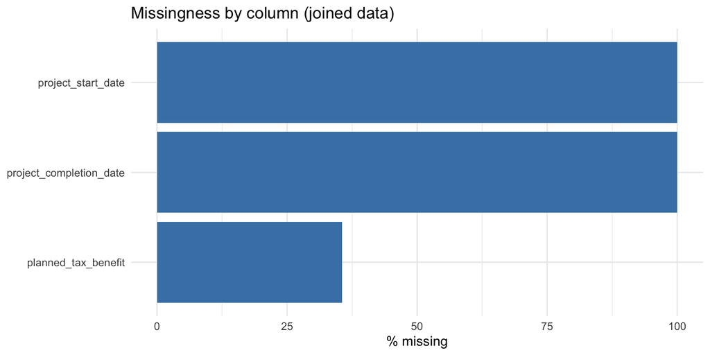

```r
tbl_miss <- tibble::tibble(
  column = names(df_joined),
  pct_missing = round(100 * colSums(is.na(df_joined)) / nrow(df_joined), 1)
) %>%
  dplyr::filter(pct_missing > 0) %>%
  dplyr::arrange(dplyr::desc(pct_missing))
if (nrow(tbl_miss) > 0) {
  p_miss <- ggplot2::ggplot(tbl_miss, ggplot2::aes(x = reorder(column, pct_missing), y = pct_missing)) +
    ggplot2::geom_col(fill = "steelblue") +
    ggplot2::coord_flip() +
    ggplot2::labs(x = NULL, y = "% missing", title = "Missingness by column (joined data)") +
    ggplot2::theme_minimal()
  print(p_miss)
  dir_fig <- here::here("outputs", "figures")
  if (!dir.exists(dir_fig)) dir.create(dir_fig, recursive = TRUE)
  ggplot2::ggsave(file.path(dir_fig, "fig_01_missingness.png"), p_miss, width = 8, height = 6, dpi = 150)
}
```

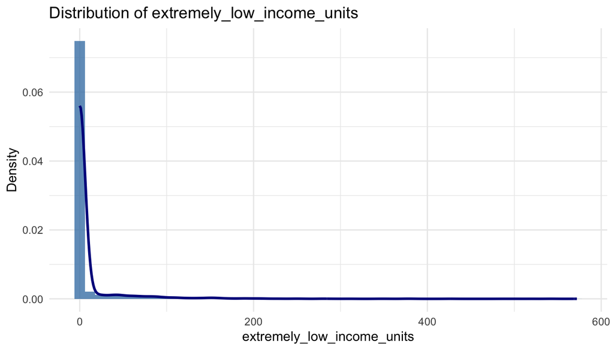

```r
if (length(unit_cols) > 0 && first_unit_col %in% names(df_joined)) {
  p_dist <- ggplot2::ggplot(df_joined, ggplot2::aes(x = .data[[first_unit_col]])) +
    ggplot2::geom_histogram(ggplot2::aes(y = after_stat(density)), bins = 50, fill = "steelblue", alpha = 0.8) +
    ggplot2::geom_density(ggplot2::aes(y = after_stat(density)), linewidth = 1, color = "darkblue") +
    ggplot2::labs(x = first_unit_col, y = "Density", title = paste("Distribution of", first_unit_col)) +
    ggplot2::theme_minimal()
  print(p_dist)
  dir_fig <- here::here("outputs", "figures")
  if (!dir.exists(dir_fig)) dir.create(dir_fig, recursive = TRUE)
  ggplot2::ggsave(file.path(dir_fig, "fig_02_distribution_units.png"), p_dist, width = 7, height = 4, dpi = 150)
}
```

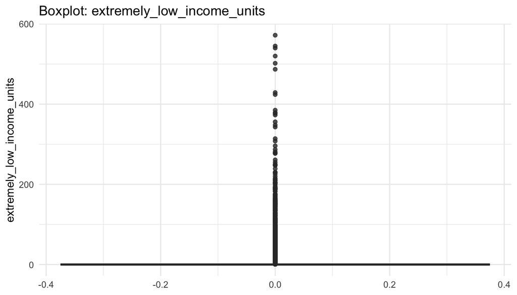

```r
if (first_unit_col %in% names(df_joined)) {
  p_box <- ggplot2::ggplot(df_joined, ggplot2::aes(y = .data[[first_unit_col]])) +
    ggplot2::geom_boxplot(fill = "steelblue", alpha = 0.8) +
    ggplot2::labs(y = first_unit_col, title = paste("Boxplot:", first_unit_col)) +
    ggplot2::theme_minimal()
  print(p_box)
  dir_fig <- here::here("outputs", "figures")
  if (!dir.exists(dir_fig)) dir.create(dir_fig, recursive = TRUE)
  ggplot2::ggsave(file.path(dir_fig, "fig_02b_boxplot_units.png"), p_box, width = 7, height = 4, dpi = 150)
}
```

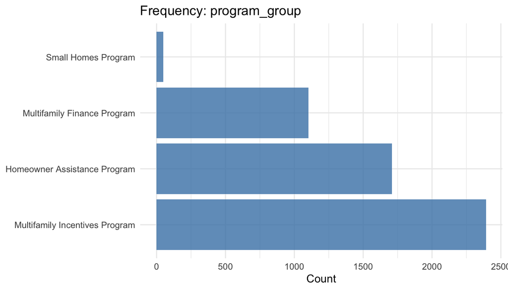

```r
cat_col <- names(df_joined)[grep("program|group|status", names(df_joined), ignore.case = TRUE)[1]]
if (is.na(cat_col)) cat_col <- names(df_joined)[purrr::map_lgl(df_joined, is.character)][1]
if (!is.na(cat_col) && cat_col %in% names(df_joined)) {
  freq_cat <- janitor::tabyl(df_joined[[cat_col]]) %>%
    janitor::adorn_pct_formatting(digits = 1)
  knitr::kable(freq_cat, format = "html") %>%
    kableExtra::kable_styling(bootstrap_options = c("striped", "condensed"), full_width = FALSE)
  p_cat <- ggplot2::ggplot(df_joined, ggplot2::aes(x = forcats::fct_infreq(.data[[cat_col]]))) +
    ggplot2::geom_bar(fill = "steelblue", alpha = 0.8) +
    ggplot2::coord_flip() +
    ggplot2::labs(x = NULL, y = "Count", title = paste("Frequency:", cat_col)) +
    ggplot2::theme_minimal()
  print(p_cat)
  dir_fig <- here::here("outputs", "figures")
  if (!dir.exists(dir_fig)) dir.create(dir_fig, recursive = TRUE)
  ggplot2::ggsave(file.path(dir_fig, "fig_02c_categorical.png"), p_cat, width = 7, height = 4, dpi = 150)
}
```

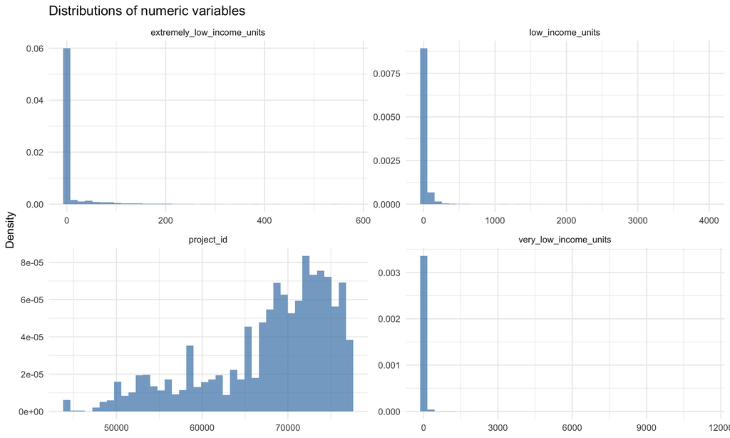

```r
if (length(num_vars) >= 2) {
  long_num <- df_joined %>% dplyr::select(dplyr::all_of(num_vars[1:min(4, length(num_vars))])) %>%
    tidyr::pivot_longer(dplyr::everything(), names_to = "variable", values_to = "value")
  p_multi <- ggplot2::ggplot(long_num, ggplot2::aes(x = value)) +
    ggplot2::geom_histogram(ggplot2::aes(y = after_stat(density)), bins = 40, fill = "steelblue", alpha = 0.7) +
    ggplot2::facet_wrap(~ variable, scales = "free", ncol = 2) +
    ggplot2::labs(x = NULL, y = "Density", title = "Distributions of numeric variables") +
    ggplot2::theme_minimal()
  print(p_multi)
  dir_fig <- here::here("outputs", "figures")
  if (!dir.exists(dir_fig)) dir.create(dir_fig, recursive = TRUE)
  ggplot2::ggsave(file.path(dir_fig, "fig_02d_multi_dist.png"), p_multi, width = 10, height = 6, dpi = 150)
}
```

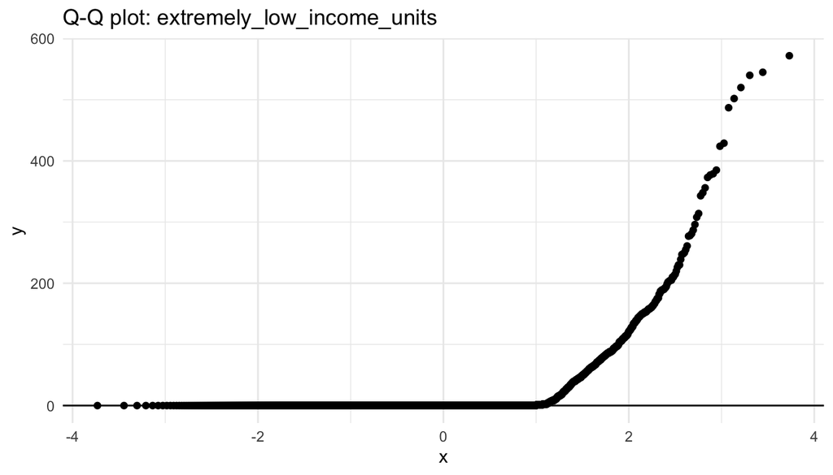

```r
if (first_unit_col %in% names(df_joined)) {
  p_qq <- ggplot2::ggplot(df_joined, ggplot2::aes(sample = .data[[first_unit_col]])) +
    ggplot2::geom_qq() + ggplot2::geom_qq_line() +
    ggplot2::labs(title = paste("Q-Q plot:", first_unit_col)) +
    ggplot2::theme_minimal()
  print(p_qq)
  dir_fig <- here::here("outputs", "figures")
  if (!dir.exists(dir_fig)) dir.create(dir_fig, recursive = TRUE)
  ggplot2::ggsave(file.path(dir_fig, "fig_02e_qq.png"), p_qq, width = 6, height = 5, dpi = 150)
}
```

## Bivariate and by subgroup

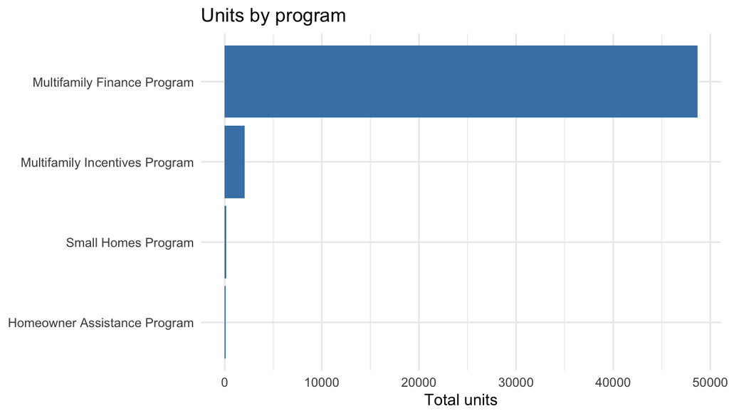

```r
program_col <- names(df_joined)[grep("program", names(df_joined), ignore.case = TRUE)[1]]
if (is.na(program_col)) program_col <- names(df_joined)[2]
unit_agg_col <- first_unit_col
if (program_col %in% names(df_joined) && unit_agg_col %in% names(df_joined)) {
  by_program <- df_joined %>%
    dplyr::group_by(dplyr::across(dplyr::all_of(program_col))) %>%
    dplyr::summarise(n = dplyr::n(), total_units = sum(.data[[unit_agg_col]], na.rm = TRUE), .groups = "drop") %>%
    dplyr::arrange(dplyr::desc(total_units))
  p_program <- ggplot2::ggplot(by_program, ggplot2::aes(x = reorder(.data[[program_col]], total_units), y = total_units)) +
    ggplot2::geom_col(fill = "steelblue") +
    ggplot2::coord_flip() +
    ggplot2::labs(x = NULL, y = "Total units", title = "Units by program") +
    ggplot2::theme_minimal()
  print(p_program)
  dir_fig <- here::here("outputs", "figures")
  if (!dir.exists(dir_fig)) dir.create(dir_fig, recursive = TRUE)
  ggplot2::ggsave(file.path(dir_fig, "fig_03_units_by_program.png"), p_program, width = 7, height = 4, dpi = 150)
}
```

Same aggregation in base R below; rest of report uses tidyverse.

```r
if (program_col %in% names(df_joined) && unit_agg_col %in% names(df_joined)) {
  by_program_base <- aggregate(
    as.formula(paste(unit_agg_col, "~", program_col)),
    data = df_joined,
    FUN = function(x) sum(x, na.rm = TRUE)
  )
  names(by_program_base)[2] <- "total_units"
  by_program_base <- by_program_base[order(-by_program_base$total_units), ]
  knitr::kable(by_program_base, format = "html", digits = 0) %>%
    kableExtra::kable_styling(bootstrap_options = c("striped", "condensed"), full_width = FALSE)
}
```

|  | program_group | total_units |
| --- | --- | --- |
| 2 | Multifamily Finance Program | 48675 |
| 3 | Multifamily Incentives Program | 2041 |
| 4 | Small Homes Program | 168 |
| 1 | Homeowner Assistance Program | 100 |

Units by borough.

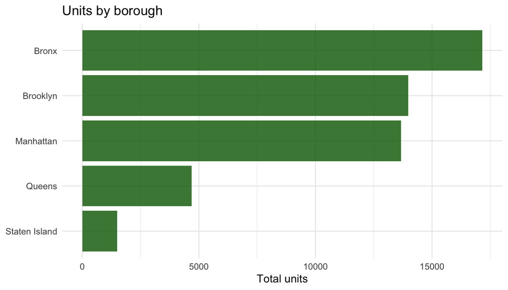

```r
if (borough_col %in% names(df_joined) && unit_agg_col %in% names(df_joined)) {
  by_borough <- df_joined %>%
    dplyr::filter(!is.na(.data[[borough_col]])) %>%
    dplyr::group_by(dplyr::across(dplyr::all_of(borough_col))) %>%
    dplyr::summarise(n = dplyr::n(), total_units = sum(.data[[unit_agg_col]], na.rm = TRUE), .groups = "drop") %>%
    dplyr::arrange(dplyr::desc(total_units))
  knitr::kable(by_borough, format = "html") %>%
    kableExtra::kable_styling(bootstrap_options = c("striped", "condensed"), full_width = FALSE)
  p_borough <- ggplot2::ggplot(by_borough, ggplot2::aes(x = reorder(.data[[borough_col]], total_units), y = total_units)) +
    ggplot2::geom_col(fill = "darkgreen", alpha = 0.8) +
    ggplot2::coord_flip() +
    ggplot2::labs(x = NULL, y = "Total units", title = "Units by borough") +
    ggplot2::theme_minimal()
  print(p_borough)
  dir_fig <- here::here("outputs", "figures")
  if (!dir.exists(dir_fig)) dir.create(dir_fig, recursive = TRUE)
  ggplot2::ggsave(file.path(dir_fig, "fig_04_units_by_borough.png"), p_borough, width = 7, height = 4, dpi = 150)
}
```

## Correlation

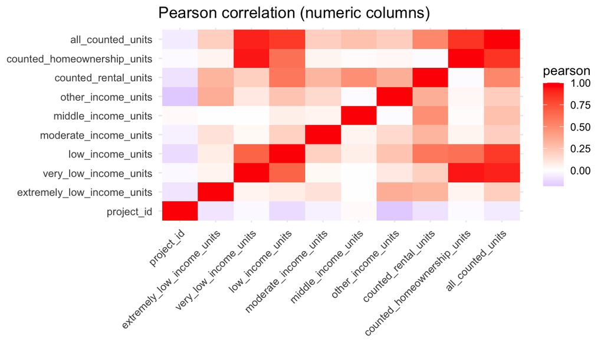

```r
num_cols <- names(df_joined)[purrr::map_lgl(df_joined, is.numeric)]
num_cols <- num_cols[!is.na(num_cols)][1:min(10, length(num_cols))]
if (length(num_cols) >= 2) {
  cor_pearson <- cor(df_joined[num_cols], use = "pairwise.complete.obs", method = "pearson")
  cor_long_p <- as.data.frame(as.table(cor_pearson)) %>%
    setNames(c("var1", "var2", "pearson"))
  p_cor <- ggplot2::ggplot(cor_long_p, ggplot2::aes(var1, var2, fill = pearson)) +
    ggplot2::geom_tile() +
    ggplot2::scale_fill_gradient2(low = "blue", mid = "white", high = "red", midpoint = 0) +
    ggplot2::labs(x = NULL, y = NULL, title = "Pearson correlation (numeric columns)") +
    ggplot2::theme_minimal() +
    ggplot2::theme(axis.text.x = ggplot2::element_text(angle = 45, hjust = 1))
  print(p_cor)
  dir_fig <- here::here("outputs", "figures")
  if (!dir.exists(dir_fig)) dir.create(dir_fig, recursive = TRUE)
  ggplot2::ggsave(file.path(dir_fig, "fig_06_correlation_pearson.png"), p_cor, width = 7, height = 6, dpi = 150)
}
```

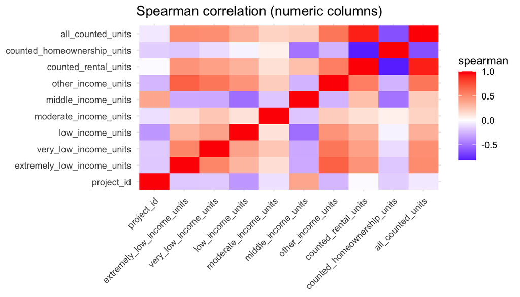

```r
if (length(num_cols) >= 2) {
  cor_spearman <- cor(df_joined[num_cols], use = "pairwise.complete.obs", method = "spearman")
  cor_long_s <- as.data.frame(as.table(cor_spearman)) %>%
    setNames(c("var1", "var2", "spearman"))
  p_cor_s <- ggplot2::ggplot(cor_long_s, ggplot2::aes(var1, var2, fill = spearman)) +
    ggplot2::geom_tile() +
    ggplot2::scale_fill_gradient2(low = "blue", mid = "white", high = "red", midpoint = 0) +
    ggplot2::labs(x = NULL, y = NULL, title = "Spearman correlation (numeric columns)") +
    ggplot2::theme_minimal() +
    ggplot2::theme(axis.text.x = ggplot2::element_text(angle = 45, hjust = 1))
  print(p_cor_s)
  dir_fig <- here::here("outputs", "figures")
  if (!dir.exists(dir_fig)) dir.create(dir_fig, recursive = TRUE)
  ggplot2::ggsave(file.path(dir_fig, "fig_06b_correlation_spearman.png"), p_cor_s, width = 7, height = 6, dpi = 150)
}
```

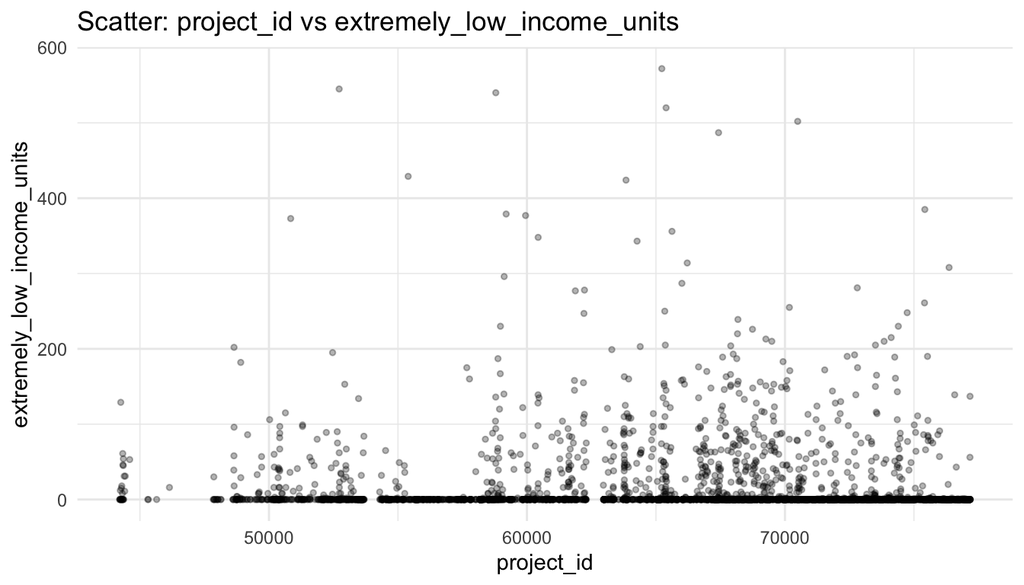

```r
dir_fig <- here::here("outputs", "figures")
if (length(num_cols) >= 2) {
  x_scatter <- num_cols[1]
  y_scatter <- num_cols[min(2, length(num_cols))]
  p_scatter <- ggplot2::ggplot(df_joined, ggplot2::aes(x = .data[[x_scatter]], y = .data[[y_scatter]])) +
    ggplot2::geom_point(alpha = 0.3, size = 1) +
    ggplot2::labs(x = x_scatter, y = y_scatter, title = paste("Scatter:", x_scatter, "vs", y_scatter)) +
    ggplot2::theme_minimal()
  print(p_scatter)
  ggplot2::ggsave(file.path(dir_fig, "fig_06c_scatter.png"), p_scatter, width = 7, height = 5, dpi = 150)
}
```

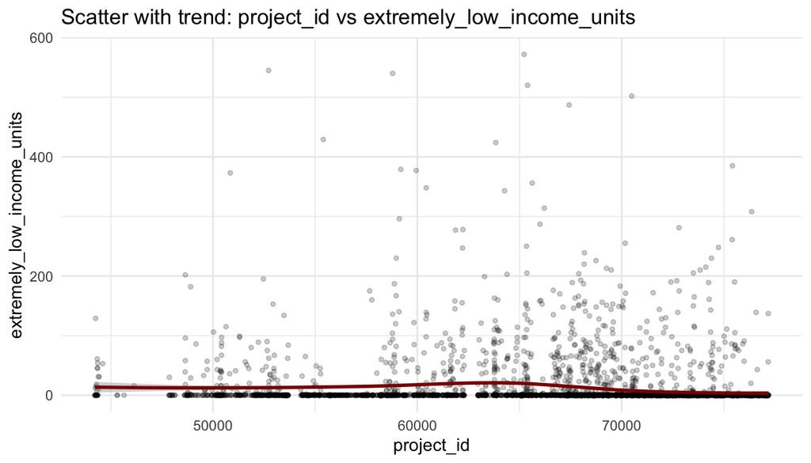

```r
if (length(num_cols) >= 2) {
  x_s <- num_cols[1]
  y_s <- num_cols[min(2, length(num_cols))]
  p_smooth <- ggplot2::ggplot(df_joined, ggplot2::aes(x = .data[[x_s]], y = .data[[y_s]])) +
    ggplot2::geom_point(alpha = 0.2, size = 1) +
    ggplot2::geom_smooth(method = "loess", se = TRUE, color = "darkred", linewidth = 1) +
    ggplot2::labs(x = x_s, y = y_s, title = paste("Scatter with trend:", x_s, "vs", y_s)) +
    ggplot2::theme_minimal()
  print(p_smooth)
  dir_fig <- here::here("outputs", "figures")
  ggplot2::ggsave(file.path(dir_fig, "fig_06c2_scatter_smooth.png"), p_smooth, width = 7, height = 5, dpi = 150)
}
```

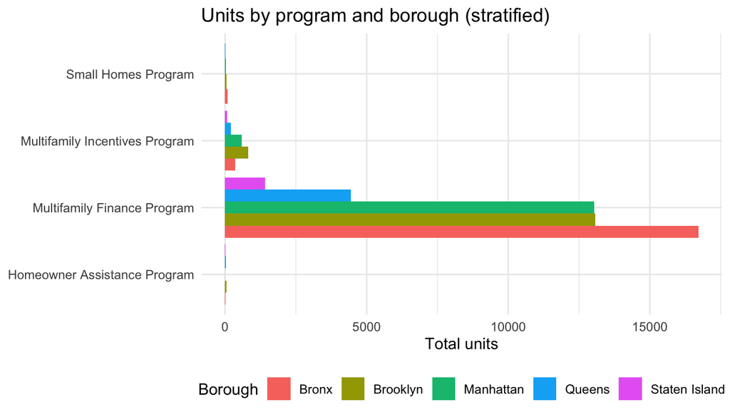

```r
if (program_col %in% names(df_joined) && borough_col %in% names(df_joined) && unit_agg_col %in% names(df_joined)) {
  strat <- df_joined %>% dplyr::filter(!is.na(.data[[borough_col]]), !is.na(.data[[program_col]])) %>%
    dplyr::group_by(dplyr::across(dplyr::all_of(c(program_col, borough_col)))) %>%
    dplyr::summarise(total_units = sum(.data[[unit_agg_col]], na.rm = TRUE), n = dplyr::n(), .groups = "drop")
  p_strat <- ggplot2::ggplot(strat, ggplot2::aes(x = .data[[program_col]], y = total_units, fill = .data[[borough_col]])) +
    ggplot2::geom_col(position = "dodge") +
    ggplot2::coord_flip() +
    ggplot2::labs(x = NULL, y = "Total units", title = "Units by program and borough (stratified)", fill = "Borough") +
    ggplot2::theme_minimal() +
    ggplot2::theme(legend.position = "bottom")
  print(p_strat)
  dir_fig <- here::here("outputs", "figures")
  ggplot2::ggsave(file.path(dir_fig, "fig_06e_stratified.png"), p_strat, width = 9, height = 6, dpi = 150)
}
```

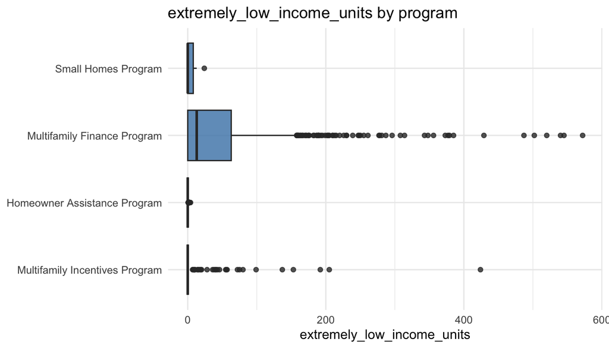

```r
if (program_col %in% names(df_joined) && unit_agg_col %in% names(df_joined)) {
  p_box_prog <- ggplot2::ggplot(df_joined, ggplot2::aes(x = forcats::fct_infreq(.data[[program_col]]), y = .data[[unit_agg_col]])) +
    ggplot2::geom_boxplot(fill = "steelblue", alpha = 0.8) +
    ggplot2::coord_flip() +
    ggplot2::labs(x = NULL, y = unit_agg_col, title = paste(unit_agg_col, "by program")) +
    ggplot2::theme_minimal()
  print(p_box_prog)
  dir_fig <- here::here("outputs", "figures")
  ggplot2::ggsave(file.path(dir_fig, "fig_06d_boxplot_by_program.png"), p_box_prog, width = 7, height = 5, dpi = 150)
}
```

```r
if (program_col %in% names(df_joined) && borough_col %in% names(df_joined)) {
  crosstab <- df_joined %>%
    dplyr::filter(!is.na(.data[[borough_col]]), !is.na(.data[[program_col]])) %>%
    dplyr::count(dplyr::across(dplyr::all_of(c(program_col, borough_col)))) %>%
    tidyr::pivot_wider(names_from = dplyr::all_of(borough_col), values_from = n, values_fill = 0)
  knitr::kable(crosstab, format = "html") %>%
    kableExtra::kable_styling(bootstrap_options = c("striped", "condensed"), full_width = FALSE)
  chi_tbl <- table(df_joined[[program_col]], df_joined[[borough_col]])
  chi_test <- try(chisq.test(chi_tbl), silent = TRUE)
  if (!inherits(chi_test, "try-error")) {
    tbl_chi <- tibble::tibble(
      test = "Chi-squared (program x borough)",
      statistic = round(chi_test$statistic, 2),
      p_value = format.pval(chi_test$p.value, digits = 3)
    )
    knitr::kable(tbl_chi, format = "html") %>%
      kableExtra::kable_styling(bootstrap_options = c("striped", "condensed"), full_width = FALSE)
  }
}
```

| test | statistic | p_value |
| --- | --- | --- |
| Chi-squared (program x borough) | 1284.54 | <2e-16 |

```r
if (exists("n_outlier_iqr")) {
  tbl_outlier <- tibble::tibble(
    method = "IQR (1.5 x IQR beyond Q1/Q3)",
    variable = unit_col_for_iqr,
    n_outliers = n_outlier_iqr,
    pct = round(100 * n_outlier_iqr / nrow(df_joined), 2)
  )
  knitr::kable(tbl_outlier, format = "html") %>%
    kableExtra::kable_styling(bootstrap_options = c("striped", "condensed"), full_width = FALSE)
}
```

| method | variable | n_outliers | pct |
| --- | --- | --- | --- |
| IQR (1.5 x IQR beyond Q1/Q3) | all_counted_units | 665 | 12.66 |

## Temporal

[figure not shown]

```r
date_col <- names(df_joined)[grep("start|date", names(df_joined), ignore.case = TRUE)[1]]
if (!is.na(date_col) && date_col %in% names(df_joined)) {
  df_joined <- df_joined %>%
    dplyr::mutate(year = lubridate::year(as.Date(.data[[date_col]], optional = TRUE)))
  by_year <- df_joined %>%
    dplyr::filter(!is.na(year)) %>%
    dplyr::group_by(year) %>%
    dplyr::summarise(n = dplyr::n(), total_units = sum(.data[[unit_agg_col]], na.rm = TRUE), .groups = "drop")
  p_year <- ggplot2::ggplot(by_year, ggplot2::aes(x = year, y = total_units)) +
    ggplot2::geom_line(linewidth = 1) +
    ggplot2::geom_point() +
    ggplot2::labs(x = "Year", y = "Total units", title = "Units by start year") +
    ggplot2::theme_minimal()
  print(p_year)
  dir_fig <- here::here("outputs", "figures")
  if (!dir.exists(dir_fig)) dir.create(dir_fig, recursive = TRUE)
  ggplot2::ggsave(file.path(dir_fig, "fig_05_units_by_year.png"), p_year, width = 7, height = 4, dpi = 150)
}
```

[figure not shown]

```r
if (borough_col %in% names(df_joined) && unit_agg_col %in% names(df_joined) && "year" %in% names(df_joined)) {
  by_year_boro <- df_joined %>% dplyr::filter(!is.na(year), !is.na(.data[[borough_col]])) %>%
    dplyr::group_by(year, .data[[borough_col]]) %>%
    dplyr::summarise(total_units = sum(.data[[unit_agg_col]], na.rm = TRUE), .groups = "drop")
  p_year_boro <- ggplot2::ggplot(by_year_boro, ggplot2::aes(x = year, y = total_units, color = .data[[borough_col]])) +
    ggplot2::geom_line(linewidth = 1) + ggplot2::geom_point() +
    ggplot2::labs(x = "Year", y = "Total units", title = "Units by year and borough", color = "Borough") +
    ggplot2::theme_minimal() + ggplot2::theme(legend.position = "bottom")
  print(p_year_boro)
  dir_fig <- here::here("outputs", "figures")
  ggplot2::ggsave(file.path(dir_fig, "fig_05b_units_by_year_borough.png"), p_year_boro, width = 8, height = 5, dpi = 150)
}
```

[figure not shown]

```r
if ("year" %in% names(df_joined) && unit_agg_col %in% names(df_joined)) {
  by_year_roll <- df_joined %>% dplyr::filter(!is.na(year)) %>%
    dplyr::group_by(year) %>%
    dplyr::summarise(total_units = sum(.data[[unit_agg_col]], na.rm = TRUE), .groups = "drop") %>%
    dplyr::arrange(year) %>%
    dplyr::mutate(
      lag1 = dplyr::lag(total_units, 1), lag2 = dplyr::lag(total_units, 2),
      rolling_3 = (total_units + lag1 + lag2) / 3
    )
  p_roll <- ggplot2::ggplot(by_year_roll, ggplot2::aes(x = year, y = total_units)) +
    ggplot2::geom_col(fill = "steelblue", alpha = 0.7) +
    ggplot2::geom_line(ggplot2::aes(y = rolling_3), color = "darkred", linewidth = 1.2) +
    ggplot2::labs(x = "Year", y = "Total units", title = "Units by year with 3-year rolling mean") +
    ggplot2::theme_minimal()
  print(p_roll)
  dir_fig <- here::here("outputs", "figures")
  ggplot2::ggsave(file.path(dir_fig, "fig_05c_rolling.png"), p_roll, width = 7, height = 4, dpi = 150)
}
```

## Geographic

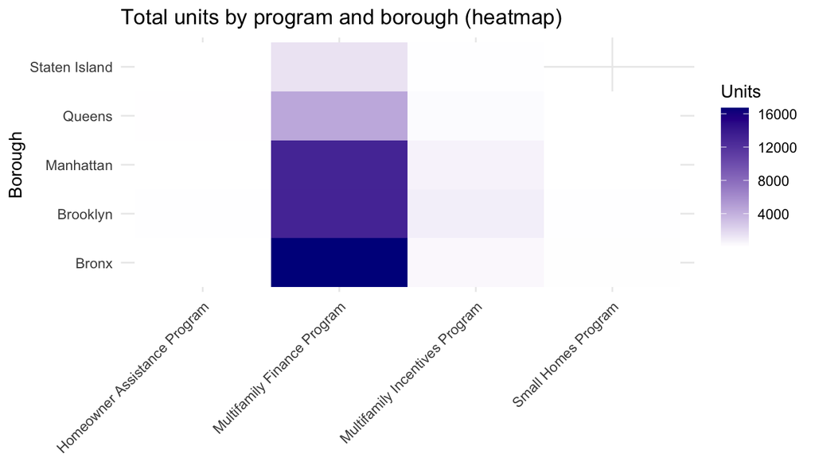

```r
if (program_col %in% names(df_joined) && borough_col %in% names(df_joined) && unit_agg_col %in% names(df_joined)) {
  heat_dat <- df_joined %>% dplyr::filter(!is.na(.data[[borough_col]]), !is.na(.data[[program_col]])) %>%
    dplyr::group_by(dplyr::across(dplyr::all_of(c(borough_col, program_col)))) %>%
    dplyr::summarise(total_units = sum(.data[[unit_agg_col]], na.rm = TRUE), .groups = "drop")
  p_heat <- ggplot2::ggplot(heat_dat, ggplot2::aes(x = .data[[program_col]], y = .data[[borough_col]], fill = total_units)) +
    ggplot2::geom_tile() +
    ggplot2::scale_fill_gradient(low = "white", high = "darkblue", na.value = "gray90") +
    ggplot2::labs(x = NULL, y = "Borough", title = "Total units by program and borough (heatmap)", fill = "Units") +
    ggplot2::theme_minimal() +
    ggplot2::theme(axis.text.x = ggplot2::element_text(angle = 45, hjust = 1))
  print(p_heat)
  dir_fig <- here::here("outputs", "figures")
  ggplot2::ggsave(file.path(dir_fig, "fig_geo_heatmap.png"), p_heat, width = 10, height = 5, dpi = 150)
}
```

```r
if (borough_col %in% names(df_joined) && unit_agg_col %in% names(df_joined)) {
  kw_test <- try(stats::kruskal.test(as.formula(paste(unit_agg_col, "~", borough_col)), data = df_joined), silent = TRUE)
  if (!inherits(kw_test, "try-error")) {
    tbl_kw <- tibble::tibble(
      test = "Kruskal-Wallis (units across boroughs)",
      statistic = round(kw_test$statistic, 3),
      p_value = format.pval(kw_test$p.value, digits = 3)
    )
    knitr::kable(tbl_kw, format = "html") %>%
      kableExtra::kable_styling(bootstrap_options = c("striped", "condensed"), full_width = FALSE)
  }
}
```

| test | statistic | p_value |
| --- | --- | --- |
| Kruskal-Wallis (units across boroughs) | 251.178 | <2e-16 |

```r
if (program_col %in% names(df_joined) && unit_agg_col %in% names(df_joined)) {
  tot_units <- sum(df_joined[[unit_agg_col]], na.rm = TRUE)
  by_prog_share <- df_joined %>%
    dplyr::group_by(dplyr::across(dplyr::all_of(program_col))) %>%
    dplyr::summarise(total_units = sum(.data[[unit_agg_col]], na.rm = TRUE), .groups = "drop") %>%
    dplyr::mutate(share_pct = round(100 * total_units / tot_units, 2)) %>%
    dplyr::arrange(dplyr::desc(total_units))
  by_prog_share$cumshare_pct <- round(cumsum(by_prog_share$share_pct), 1)
  knitr::kable(by_prog_share, format = "html", digits = 2) %>%
    kableExtra::kable_styling(bootstrap_options = c("striped", "condensed"), full_width = FALSE)
  hhi <- sum((by_prog_share$share_pct / 100)^2)
  tbl_hhi <- tibble::tibble(metric = "Herfindahl-Hirschman (program shares)", value = round(hhi, 4))
  knitr::kable(tbl_hhi, format = "html") %>%
    kableExtra::kable_styling(bootstrap_options = c("striped", "condensed"), full_width = FALSE)
}
```

| metric | value |
| --- | --- |
| Herfindahl-Hirschman (program shares) | 0.9131 |

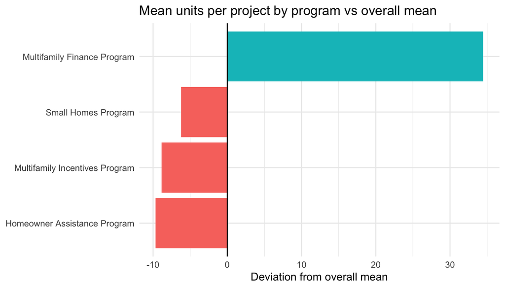

```r
if (program_col %in% names(df_joined) && unit_agg_col %in% names(df_joined)) {
  prog_means <- df_joined %>%
    dplyr::group_by(dplyr::across(dplyr::all_of(program_col))) %>%
    dplyr::summarise(mean_units = mean(.data[[unit_agg_col]], na.rm = TRUE), n = dplyr::n(), .groups = "drop")
  global_mean <- mean(df_joined[[unit_agg_col]], na.rm = TRUE)
  prog_means$deviation <- round(prog_means$mean_units - global_mean, 2)
  prog_means <- prog_means %>% dplyr::arrange(dplyr::desc(abs(deviation)))
  p_dev <- ggplot2::ggplot(prog_means, ggplot2::aes(x = reorder(.data[[program_col]], deviation), y = deviation)) +
    ggplot2::geom_col(ggplot2::aes(fill = deviation > 0)) +
    ggplot2::geom_hline(yintercept = 0, linewidth = 0.5) +
    ggplot2::coord_flip() +
    ggplot2::labs(x = NULL, y = "Deviation from overall mean", title = "Mean units per project by program vs overall mean") +
    ggplot2::theme_minimal() +
    ggplot2::theme(legend.position = "none")
  print(p_dev)
  dir_fig <- here::here("outputs", "figures")
  if (!dir.exists(dir_fig)) dir.create(dir_fig, recursive = TRUE)
  ggplot2::ggsave(file.path(dir_fig, "fig_deviation.png"), p_dev, width = 8, height = 5, dpi = 150)
}
```

# Map

```r
has_sf <- requireNamespace("sf", quietly = TRUE)
has_tmap <- requireNamespace("tmap", quietly = TRUE)
borough_url <- "https://data.cityofnewyork.us/api/geospatial/tqmj-j8zm?method=export&format=GeoJSON"
borough_sf <- if (has_sf) try(sf::st_read(borough_url, quiet = TRUE), silent = TRUE) else "no_sf"
if (has_sf && has_tmap && !inherits(borough_sf, "try-error") && borough_col %in% names(df_joined)) {
  by_borough_map <- df_joined %>%
    dplyr::filter(!is.na(.data[[borough_col]])) %>%
    dplyr::group_by(dplyr::across(dplyr::all_of(borough_col))) %>%
    dplyr::summarise(total_units = sum(.data[[unit_agg_col]], na.rm = TRUE), .groups = "drop")
  name_in_sf <- names(borough_sf)[grep("boro|name", names(borough_sf), ignore.case = TRUE)[1]]
  if (is.na(name_in_sf)) name_in_sf <- names(borough_sf)[1]
  borough_sf <- borough_sf %>%
    dplyr::mutate(boro_match = toupper(substr(.data[[name_in_sf]], 1, 1)))
  by_borough_map <- by_borough_map %>%
    dplyr::mutate(boro_match = toupper(substr(as.character(.data[[borough_col]]), 1, 1)))
  borough_sf <- borough_sf %>%
    dplyr::left_join(by_borough_map, by = c("boro_match" = "boro_match"))
  tm <- tmap::tm_shape(borough_sf) +
    tmap::tm_polygons("total_units", title = "Total units") +
    tmap::tm_layout(main.title = "Units by borough")
  print(tm)
  dir_fig <- here::here("outputs", "figures")
  if (!dir.exists(dir_fig)) dir.create(dir_fig, recursive = TRUE)
  tmap::tmap_save(tm, file.path(dir_fig, "fig_07_borough_map.png"), width = 7, height = 6, dpi = 150)
}
```

# Summary

Project-level table: 5252 rows; building-level: 8604 rows. After join: 5252 rows (5252 with borough, 0 without).